# 存活分析 期末報告

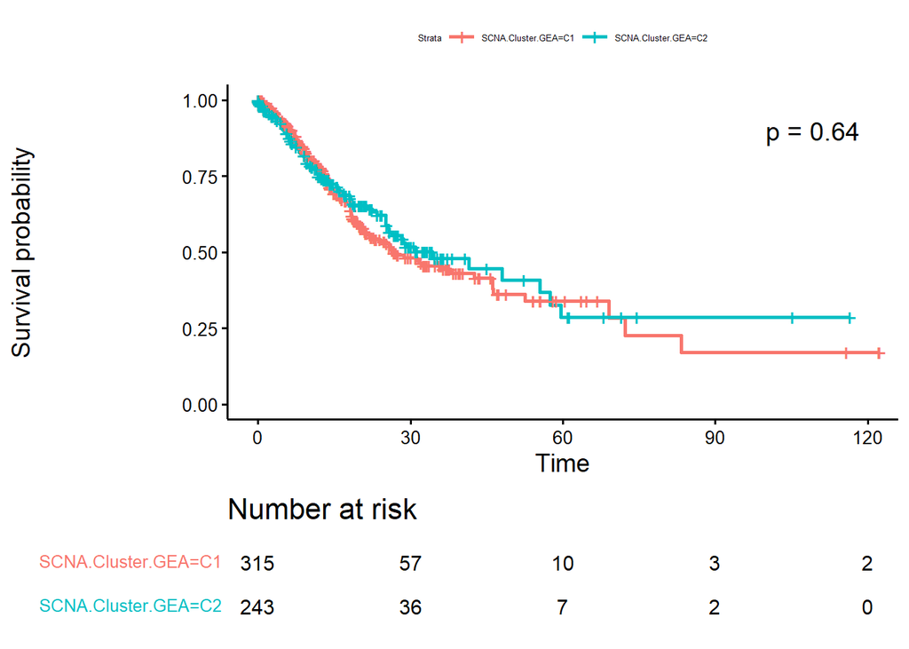

```r
fit.rank21 = survfit(Surv(Overall.Survival..Months.,Overall.Survival.Status) ~ SCNA.Cluster.GEA, data=data4, conf.type="log-log")

ggsurvplot(fit.rank21,
           pval = TRUE,
           font.tickslab = 10,
           font.legend = 5,
           pval.coord = c(100,0.9),
           conf.int = FALSE,
           risk.table = T,
           fontsize = 4,
           tables.theme = clean_theme())
```

- p = 0.64 > 0.05，不拒絕H0，SCNA.Cluster.GEA 不顯著影響生存函數
22. Sex : 性別

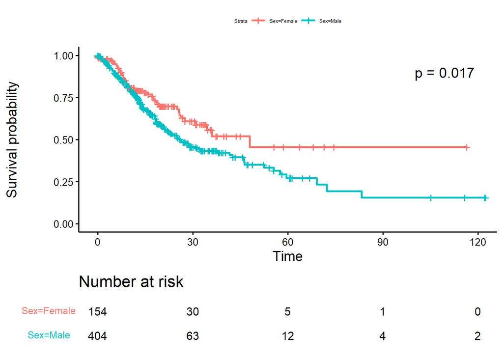

```r
fit.rank22 = survfit(Surv(Overall.Survival..Months.,Overall.Survival.Status) ~ Sex, data=data4, conf.type="log-log")

ggsurvplot(fit.rank22,
           pval = TRUE,
           font.tickslab = 10,
           font.legend = 5,
           pval.coord = c(100,0.9),
           conf.int = FALSE,
           risk.table = T,
           fontsize = 4,
           tables.theme = clean_theme())
```

- p = 0.017 < 0.05，拒絕H0，Sex 顯著影響生存函數
23. TP53.Protein.Coding : TP53 蛋白質編碼，(int.0:NO,1:YES)

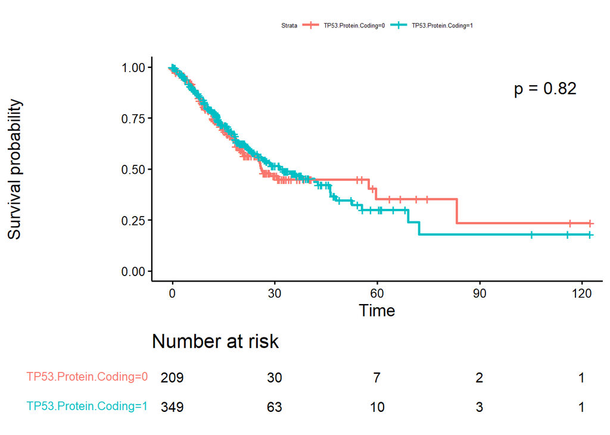

```r
fit.rank23 = survfit(Surv(Overall.Survival..Months.,Overall.Survival.Status) ~ TP53.Protein.Coding, data=data4, conf.type="log-log")

ggsurvplot(fit.rank23,
           pval = TRUE,
           font.tickslab = 10,
           font.legend = 5,
           pval.coord = c(100,0.9),
           conf.int = FALSE,
           risk.table = T,
           fontsize = 4,
           tables.theme = clean_theme())
```

- p = 0.82 > 0.05，不拒絕H0，TP53.Protein.Coding 不顯著影響生存函數
24. Tumor.Stage : 腫瘤階段，(chr.)

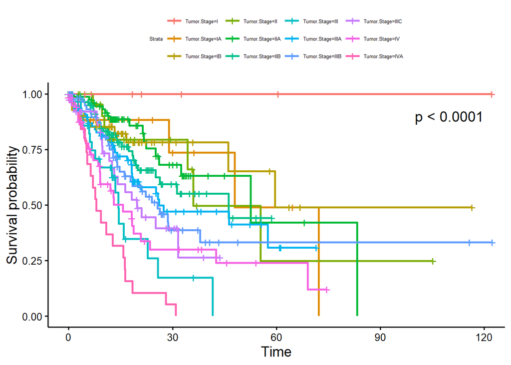

```r
fit.rank24 = survfit(Surv(Overall.Survival..Months.,Overall.Survival.Status) ~ Tumor.Stage, data=data4, conf.type="log-log")

ggsurvplot(fit.rank24,
           pval = TRUE,
           font.tickslab = 10,
           font.legend = 5,
           pval.coord = c(100,0.9),
           conf.int = FALSE,
           risk.table = F,
           fontsize = 4,
           tables.theme = clean_theme())
```

- p < 0.0001 < 0.05，拒絕H0，Tumor.Stage 顯著影響生存函數

```r
# arrange_ggsurvplots(list(res, res2),
#                    ncol=1, nrow=2,
#                    risk.table.height = -0.1)
```

### 24個類別變數中，以下9個變數分不分組對危險函數有顯著差別

3. Country : 國家，(chr.)
4. Genome.Doublings : 基因體倍增，(int.)
5. Neoplasm.Histologic.Grade : 腫瘤.組織學.分級，(chr.)
6. MLH1.Methylation : MLH1甲基化，(logi.FALSE,TRUE)
7. New.Neoplasm.Event.Post.Initial.Therapy.Indicator” : 新的腫瘤。事件.後.初始.治療.指標，(chr,YES/NO)
8. Person.Neoplasm.Cancer.Status : 人體腫瘤癌症狀態，(chr.TUMOR_FREE/WITH_TUMOR)
9. Surgical.Margin.Resection.Status : 手術邊緣切除狀態，(chr.)
10. Sex : 性別
11. Tumor.Stage : 腫瘤階段，(chr.)

## 更新資料變數 : DATA5，559 obs. of 20 variables

```r
data5 = subset(data4,select = -c(ARID1A.Protein.Coding, CDKN2A.Methylation, EBV.Positive, EC,
                                 Gastric.Classification, GEA.CIN.SMG, GEA.GEJ, HER2.Amplification.Status,
                                 KRAS.Protein.Coding, MSI.Status, PIK3CA.Protein.Coding, RHOA.Protein.Coding,
                                 SCC, SCNA.Cluster.GEA, TP53.Protein.Coding))

# 挑選的變數不加引號
# str(data5) : 559 obs. of  20 variables

data5[data5$Tumor.Stage == "IA", "Tumor.Stage"] = 'I'
data5[data5$Tumor.Stage == "IB", "Tumor.Stage"] = 'I'
data5[data5$Tumor.Stage == "IIA", "Tumor.Stage"] = 'II'
data5[data5$Tumor.Stage == "IIB", "Tumor.Stage"] = 'II'
data5[data5$Tumor.Stage == "IIIA", "Tumor.Stage"] = 'III'
data5[data5$Tumor.Stage == 'IIIB', "Tumor.Stage"] = 'III'
data5[data5$Tumor.Stage == 'IIIC', "Tumor.Stage"] = 'III'
data5[data5$Tumor.Stage == "IVA", "Tumor.Stage"] = 'IV'
```

## Cox Proportional Hazard (PH) Model

### Local test

用 local test 看連續變數是否對食道癌生存有顯著影響

### **Wald test**:

- the null hypothesis/alternative hypothesis $H_0:\beta^1=\beta_{10}=(0)\;vs\;H_a:\beta^1 \neq \beta_{10}$
- the form of the test statistic and its distribution with the corresponding degrees of freedom under Ho $under\; H_0\;,\chi^2_w=(\hat{\beta^1}-\beta_{10})^T(Var(\hat{\beta^1}))^{-1}(\hat{\beta^1}-\beta_{10})$~$\chi^2_1$
- the rejection region $\chi^2_w >\chi^2_{1,0.05}\;or\;p-value<0.05$
1. Absolute.Extract.Ploidy
2. Absolute.Extract.Purity
3. Diagnosis.Age

#### **Global**

```r
### FULL MODEL
fit.loc1 = coxph(formula = Surv(Overall.Survival..Months.,Overall.Survival.Status) ~ ., data = data5)
```

#### **Local**

```r
### 1. Absolute.Extract.Ploidy
beta1hat = fit.loc1$coefficients[1]
beta10 = rep(0,1)
var11 = fit.loc1$var[1,1]
chiWald = t(beta1hat-beta10)%*%solve(var11)%*%(beta1hat-beta10)
# chiWald
1-pchisq(chiWald,1) # 0.4105631
```

```
##           [,1]
## [1,] 0.4105631
```

```r
### 2. Absolute.Extract.Purity
beta1hat = fit.loc1$coefficients[2]
beta10 = rep(0,1)
var11 = fit.loc1$var[2,2]
chiWald = t(beta1hat-beta10)%*%solve(var11)%*%(beta1hat-beta10)
# chiWald
1-pchisq(chiWald,1) # 0.1194808
```

```
##           [,1]
## [1,] 0.1194808
```

```r
### 3. Diagnosis.Age
beta1hat = fit.loc1$coefficients[3]
beta10 = rep(0,1)
var11 = fit.loc1$var[3,3]
chiWald = t(beta1hat-beta10)%*%solve(var11)%*%(beta1hat-beta10)
# chiWald
1-pchisq(chiWald,1) # 0.01779964
```

```
##            [,1]
## [1,] 0.01779964
```

#### conclusions

- pvalue:0.4105631 > 0.05，不拒絕H0，係數顯著為0，Absolute.Extract.Ploidy對食道癌生存沒有顯著影響
- pvalue:0.1194808 > 0.05，不拒絕H0，係數顯著為0，Absolute.Extract.Purity對食道癌生存沒有顯著影響
- pvalue:0.01779964 < 0.05，拒絕H0，係數不顯著為0，年齡對食道癌生存有顯著影響

### **Likelihood ratio test**:

- the null hypothesis/alternative hypothesis $H_0:\beta^1=\beta_{10}=(0)\;vs\;H_a:\beta^1 \neq \beta_{10}$
- the form of the test statistic and its distribution with the corresponding degrees of freedom under Ho $under\; H_0\;,\chi^2_{LR}=2(LL(Full)-LL(Reduced))$~$\chi^2_{35-34}$
- the rejection region $\chi^2_{LR} >\chi^2_{1,0.05}\;or\;p-value<0.05$
4. Estimated.Leukocyte.Percentage
- reduced model(Estimated.Leukocyte.Percentage係數為0)
5. Fraction.Genome.Altered
- reduced model(Fraction.Genome.Altered係數為0)
6. Mutation.Rate
- reduced model(Mutation.Rate係數為0)